# Mythbusting the Stereotypical Thai People of USA

# 1 Executive Summary

We use the `prop_df` dataset dervied from the US Census according to the `codebook` to perform proportional z-tests on characteristics of Thai population in the US and the general US population.

Note that we cherrypick only the most interesting features. Thus, this is might not be the most accurate way (p-value interpretation shenanigans aside) to prove or debunk these preconceptions about Thai people in the US and a lot of it will rely on the context; however, this is as close as aggregate numbers can take us.

# 2 They Are Lazy?

One of the strongest stereotypes about Thai people, and perhaps immigrants overall reinforced by [a certain looney-tunesque character of a presidential candidate](https://www.youtube.com/watch?v=DnpO_RTSNmQ), is that they are lazy welfare cheaters who simply came to sit around waiting to be naturalized. However, if *lazy* means unemployed, then statistics significantly disagrees with the premise (pun intended). The difference between percentage of Thai people and the general US population in the workforce is almost negligible. Approximately 65% of Thai people in the US are employed as compared to 63% of the US population. Therefore, the first myth is debunked; Thai people came to the US to work, at least as often times or more than the next American.

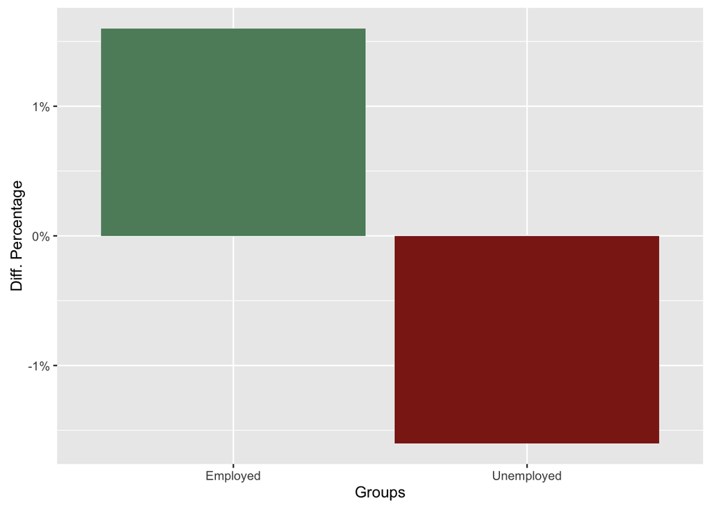

| Employment Status | % Thai | # Thai | % US | # US | Z-score |
| --- | --- | --- | --- | --- | --- |
| In.labor.force | 0.649 | 141,150 | 0.633 | 160,521,803 | 15.4746202484409 |
| Not.in.labor.force | 0.351 | 76,338 | 0.367 | 93,067,144 | -15.4746202484409 |

# 3 They Open Thai Restaurants?

But what types of work do they do? Another widespread preconception is that Thai people come to open Thai restaurants because obviously you can charge $30 for a mediocre Pad Thai that nobody would know is nothing like the authentic version (Fun fact: Pad Thai is actually NOT a traditional Thai dish per se; it was [invented during a nationalist government to reinforce ‘Thai-ness’](https://en.wikipedia.org/wiki/Pad_Thai#History)). In order to verify the claim, we first look at the difference in types of occupation. Thai people in the US are about 10% more likely to be in the service industry. This reinforces our myth.

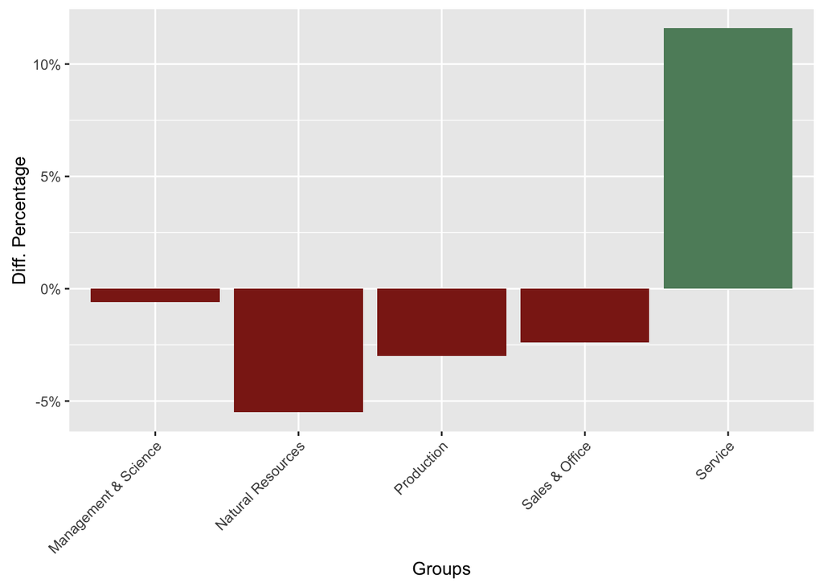

| Occupation Type | % Thai | # Thai | % US | # US | Z-score |
| --- | --- | --- | --- | --- | --- |
| Management &amp; Science | 0.363 | 47,564 | 0.369 | 54,619,346 | -4.49901993044747 |
| Service | 0.298 | 39,047 | 0.182 | 26,939,623 | 108.753624510383 |
| Sales &amp; Office | 0.213 | 27,909 | 0.237 | 35,080,718 | -20.421208562795 |
| Production | 0.093 | 12,186 | 0.123 | 18,206,449 | -33.0523553065655 |
| Natural Resources | 0.034 | 4,455 | 0.089 | 13,173,772 | -69.9050986041579 |

When we dig deeper into the industry in which Thai people work in, we found that they are 15% more likely to be in `Arts, Entertainment & Food`, which almost cries out Thai restaurant owners at an overwhelming statistical significance. It is true that without a comprehensive survey, there is no way, much of this remains a guesswork; for instance, a lot of them might be artists or performers instead of food workers. But since it is highly unlikely anyone would care about enough about Thai people in the US to do this very specific study on some 300,000 people of minority population (not to mention the oh-so-mighty Thai government whose stats bureau provides census data in [pdf](http://web.nso.go.th/en/survey/pop_character/pop_character.htm)), we make the figurative leap of faith here and ‘confirm’ that many a Thai person indeed come to the US to open Thai restaurants.

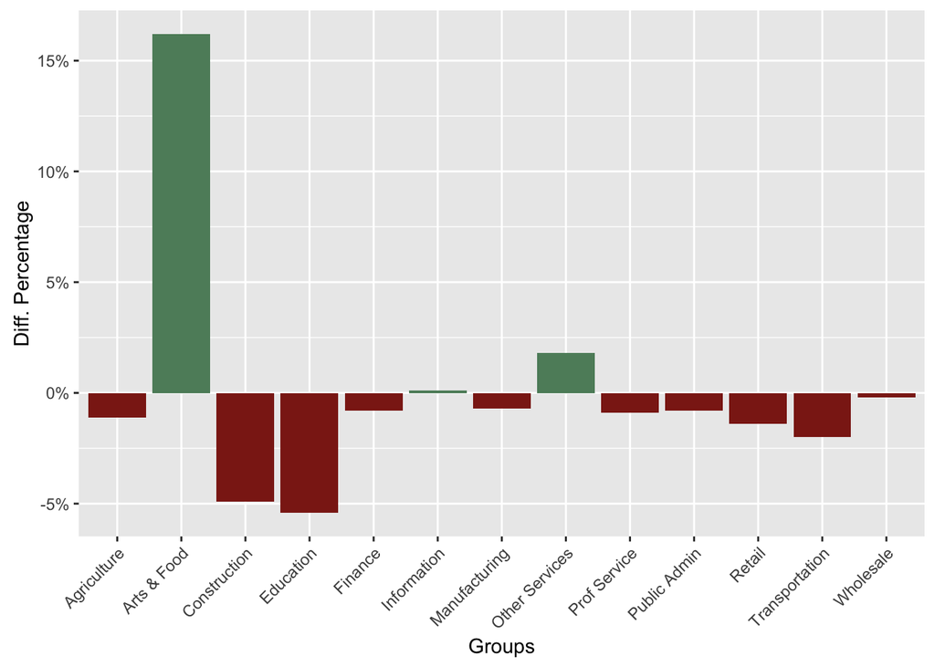

| Industry | % Thai | # Thai | % US | # US | Z-score |
| --- | --- | --- | --- | --- | --- |
| Arts &amp; Food | 0.26 | 34,068 | 0.098 | 14,505,951 | 197.019491145823 |
| Education | 0.176 | 23,061 | 0.23 | 34,044,579 | -46.4311391734072 |
| Prof Service | 0.102 | 13,365 | 0.111 | 16,430,210 | -10.3666157304548 |
| Retail | 0.101 | 13,234 | 0.115 | 17,022,289 | -15.8789234987435 |
| Manufacturing | 0.096 | 12,579 | 0.103 | 15,246,051 | -8.33274310007243 |
| Other Services | 0.067 | 8,779 | 0.049 | 7,252,975 | 30.1655005316677 |
| Finance | 0.057 | 7,469 | 0.065 | 9,621,294 | -11.7420177159416 |
| Public Admin | 0.039 | 5,110 | 0.047 | 6,956,936 | -13.6778841358609 |
| Transportation | 0.03 | 3,931 | 0.05 | 7,400,995 | -33.208496619319 |
| Wholesale | 0.025 | 3,276 | 0.027 | 3,996,538 | -4.46476657286551 |

[output cut: 3 more lines]

# 4 They Are Gold Diggers?

*Mia Farang*, literally wife of a (white) westerner, is a well-known derogatory term used to describe low-income Thai women from the rural area, most likely former prostitutes, who are preferred as exotic items by and thus married to white westerners (farang in Thai). The premise is that a lot of Thai female in the US are *Mia Farang*. The 7% difference in percentage of female population who are married between Thai and the general population might make us want to jump to conclusion and confirm the stereotype. Nonetheless, the limitation of our study means that Thai female might just tend to get married more than the general US population and not necessarily with a white male.

We took another angle and look at the difference between naturalization of Thai and the general US population. If Thai female tends to get married more (as we already confirmed) and also naturalized more, the *Mia Farang* hypothesis might be more viable. We saw that indeed Thai female are about 10% more likely than the general US population to be naturalized but this is most likely simply because there are also higher percentage of Thai female in the US than the general US population.

Unfortunately with the evidence, we have it is difficult to either debunk or confirm the Thai gold digger myth.

[figure not shown]

| Female Marital Status | % Thai | # Thai | % US | # US | Z-score |
| --- | --- | --- | --- | --- | --- |
| Now.married..except.separated | 0.532 | 73,126 | 0.461 | 60,900,749 | 52.7790231928943 |
| Never.married | 0.28 | 38,487 | 0.302 | 39,895,936 | -17.7563500145761 |
| Divorced | 0.109 | 14,982 | 0.123 | 16,249,007 | -15.7961279185292 |
| Widowed | 0.051 | 7,010 | 0.09 | 11,889,517 | -50.508408077495 |
| Separated | 0.027 | 3,711 | 0.024 | 3,170,538 | 7.26300056731098 |

| Total Marital Status | % Thai | # Thai | % US | # US | Z-score |
| --- | --- | --- | --- | --- | --- |
| Now.married..except.separated | 0.495 | 109,620 | 0.477 | 122,956,610 | 16.9518899048597 |
| Never.married | 0.354 | 78,395 | 0.333 | 85,837,633 | 20.9596799004822 |
| Divorced | 0.094 | 20,817 | 0.11 | 28,354,774 | -24.0551832658889 |
| Widowed | 0.034 | 7,529 | 0.059 | 15,208,470 | -49.9171181886737 |
| Separated | 0.023 | 5,093 | 0.021 | 5,413,184 | 6.56096774199934 |

| Naturalized by Gender | % Thai | # Thai | % US | # US | Z-score |
| --- | --- | --- | --- | --- | --- |
| Female | 0.672 | 57,684 | 0.541 | 10,811,743 | 76.8631889431065 |
| Male | 0.328 | 28,155 | 0.459 | 9,172,995 | -76.8631889431065 |

| Gender | % Thai | # Thai | % US | # US | Z-score |
| --- | --- | --- | --- | --- | --- |
| Female | 0.595 | 169,198 | 0.508 | 161,979,384 | 92.7579603808562 |
| Male | 0.405 | 115,168 | 0.492 | 156,877,672 | -92.7579603808563 |